# Homework 6

Ashley King

4/25/2020

## 9. In this exercise, we will predict the number of applications received using the other variables in the College data set.

### (a) Split the data set into a training set and a test set.

```r
set.seed(111)
total_length = nrow(College)
train = sample(total_length, total_length * 0.70)
training_data = College[train,]
test = College[-train,]
```

### (b) Fit a linear model using least squares on the training set, and report the test error obtained.

```r
college_model = lm(Apps ~ ., data = College, subset = train)
summary(college_model)
```

```
##
## Call:
## lm(formula = Apps ~ ., data = College, subset = train)
##
## Residuals:
##     Min      1Q  Median      3Q     Max
## -5114.0  -429.3   -13.0   351.5  7543.8
##
## Coefficients:
##               Estimate Std. Error t value Pr(>|t|)
## (Intercept) -2.608e+02  4.930e+02  -0.529 0.597020
## PrivateYes  -5.049e+02  1.718e+02  -2.940 0.003430 **
## Accept       1.599e+00  4.731e-02  33.810  < 2e-16 ***
## Enroll      -9.268e-01  2.380e-01  -3.894 0.000111 ***
## Top10perc    5.289e+01  6.748e+00   7.837 2.57e-14 ***
## Top25perc   -1.430e+01  5.406e+00  -2.646 0.008395 **
## F.Undergrad  7.450e-02  4.148e-02   1.796 0.073055 .
## P.Undergrad -9.159e-03  4.922e-02  -0.186 0.852469
## Outstate    -9.081e-02  2.333e-02  -3.892 0.000112 ***
## Room.Board   1.737e-01  5.861e-02   2.964 0.003178 **
## Books       -1.731e-02  2.713e-01  -0.064 0.949168
## Personal     2.975e-02  7.376e-02   0.403 0.686839
## PhD         -8.767e+00  6.025e+00  -1.455 0.146215
## Terminal    -4.666e+00  6.470e+00  -0.721 0.471127
## S.F.Ratio    7.747e+00  1.705e+01   0.454 0.649678
## perc.alumni -9.718e-01  4.984e+00  -0.195 0.845482
## Expend       5.899e-02  1.573e-02   3.749 0.000197 ***
## Grad.Rate    1.082e+01  3.673e+00   2.946 0.003358 **
## ---
## Signif. codes:  0 '***' 0.001 '**' 0.01 '*' 0.05 '.' 0.1 ' ' 1
##
## Residual standard error: 1066 on 525 degrees of freedom
## Multiple R-squared:  0.9278, Adjusted R-squared:  0.9255
## F-statistic: 396.9 on 17 and 525 DF,  p-value: < 2.2e-16
```

```r
linear_predicted = predict(college_model, test)
linear_error = mean((linear_predicted - test$Apps)^2)
linear_error
```

```
## [1] 1010347
```

- The test MSE for the linear model is 1.01034710^{6}
- This appears to be a high error, but we need to compare it to some other models to know.

### (c) Fit a ridge regression model on the training set, with λ chosen by cross-validation. Report the test error obtained.

```r
train_x = model.matrix(Apps~., training_data)
train_y = training_data$Apps
test_x = model.matrix(Apps~., test)
test_y = test$Apps

ridge.mod = glmnet(train_x, train_y, alpha = 0, lambda = grid, thresh = 1e-12)
```

```r
cv.out = cv.glmnet(train_x, train_y, alpha = 0)
bestlam = cv.out$lambda.min
bestlam
```

```
## [1] 368.4843
```

- Our lambda value is 368.4842616

```r
ridge.pred = predict(ridge.mod,s = bestlam,newx = test_x)

# Using the best-lambda chosen from cross validation we will calculate the test MSE for the test data.
ridge_error = mean((ridge.pred-test_y)^2)
ridge_error
```

```
## [1] 1150592
```

- The test MSE is 1.150592210^{6}
- This model has a higher error than the linear model.

### (d) Fit a lasso model on the training set, with λ chosen by crossvalidation. Report the test error obtained, along with the number of non-zero coefficient estimates.

```r
lasso.mod = glmnet(train_x, train_y, alpha = 1, lambda = grid, thresh = 1e-12)

cv.out = cv.glmnet(train_x, train_y, alpha = 1)

bestlam = cv.out$lambda.min
bestlam
```

```
## [1] 38.60299
```

```r
lasso.pred = predict(lasso.mod, s = bestlam, newx = test_x)
lasso_error = mean((lasso.pred-test_y)^2)
lasso_error
```

```
## [1] 1075249
```

- The test MSE is 1.075248710^{6}
- Our lasso model performs worse than the linear model but better than the ridge model.

```r
x = model.matrix(Apps~.,College)[,-1]
y = College$Apps

out = glmnet(x, y, alpha = 1, lambda = bestlam)

lasso.coef = predict(out, type = "coefficients", s = bestlam)[1:18,]
lasso.coef[lasso.coef != 0]
```

```
##   (Intercept)    PrivateYes        Accept     Top10perc      Outstate
## -704.64149311 -349.40625281    1.39400202   28.19321058   -0.03628558
##    Room.Board           PhD      Terminal   perc.alumni        Expend
##    0.09509002   -3.18001297   -2.56559485   -0.52364541    0.06123312
##     Grad.Rate
##    2.89615723
```

- These are the non-zero coefficient estimates, there are 10 total.

### (e) Fit a PCR model on the training set, with M chosen by crossvalidation. Report the test error obtained, along with the value of M selected by cross-validation.

```r
pcr_College = pcr(Apps ~ ., data = training_data,  scale = TRUE, validation = "CV")
summary(pcr_College)
```

```
## Data:    X dimension: 543 17
##  Y dimension: 543 1
## Fit method: svdpc
## Number of components considered: 17
##
## VALIDATION: RMSEP
## Cross-validated using 10 random segments.
##        (Intercept)  1 comps  2 comps  3 comps  4 comps  5 comps  6 comps
## CV            3907     3908     2108     2109     2086     1695     1666
## adjCV         3907     3908     2105     2107     2136     1677     1661
##        7 comps  8 comps  9 comps  10 comps  11 comps  12 comps  13 comps
## CV        1666     1667     1583      1587      1594      1598      1617
## adjCV     1661     1664     1577      1581      1588      1592      1611
##        14 comps  15 comps  16 comps  17 comps
## CV         1617      1565      1293      1241
## adjCV      1617      1535      1280      1230
##
## TRAINING: % variance explained
##       1 comps  2 comps  3 comps  4 comps  5 comps  6 comps  7 comps  8 comps
## X     31.8832    57.47    64.57    70.22    75.63    80.58    84.38    87.69
## Apps   0.7077    71.74    71.95    72.08    83.06    83.39    83.43    83.48
##       9 comps  10 comps  11 comps  12 comps  13 comps  14 comps  15 comps
## X       90.64     93.00     95.09     96.85     97.91     98.66     99.33
## Apps    85.23     85.33     85.35     85.35     85.37     85.47     90.89
##       16 comps  17 comps
## X        99.83    100.00
## Apps     92.38     92.78
```

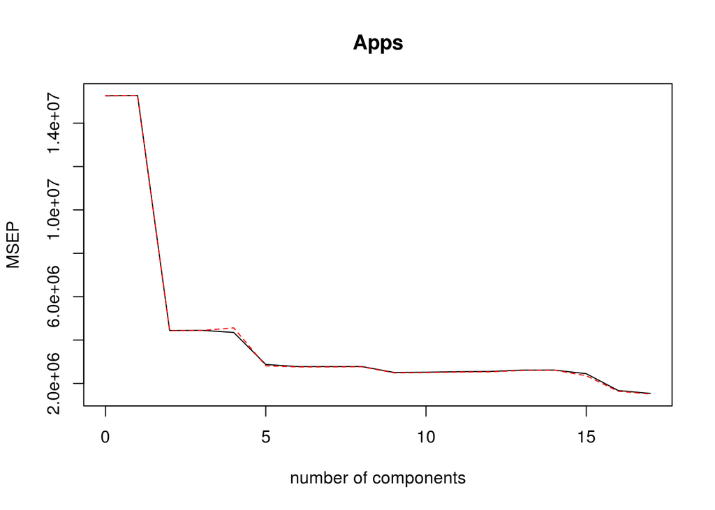

```r
validationplot(pcr_College,val.type = "MSEP")
```

- It appears that the best point is around 16-17, as those are the lowest points

```r
pcr.pred = predict(pcr_College, College[-train,], ncomp =  17)
pcr_error = mean((pcr.pred-test_y)^2)
pcr_error
```

```
## [1] 1010347
```

- The PCR test MSE is 1.01034710^{6}
- Although this outperforms the lasso and ridge model, it interestingly has the same performance as the linear model

### (f) Fit a PLS model on the training set, with M chosen by crossvalidation. Report the test error obtained, along with the value of M selected by cross-validation.

```r
pls.fit = plsr(Apps~., data = College, subset = train, scale = TRUE, validation = "CV")
summary(pls.fit)
```

```
## Data:    X dimension: 543 17
##  Y dimension: 543 1
## Fit method: kernelpls
## Number of components considered: 17
##
## VALIDATION: RMSEP
## Cross-validated using 10 random segments.
##        (Intercept)  1 comps  2 comps  3 comps  4 comps  5 comps  6 comps
## CV            3907     1928     1591     1544     1468     1398     1264
## adjCV         3907     1924     1577     1546     1449     1379     1251
##        7 comps  8 comps  9 comps  10 comps  11 comps  12 comps  13 comps
## CV        1253     1245     1244      1242      1241      1241      1240
## adjCV     1241     1233     1232      1231      1230      1230      1229
##        14 comps  15 comps  16 comps  17 comps
## CV         1241      1241      1241      1241
## adjCV      1229      1229      1229      1229
##
## TRAINING: % variance explained
##       1 comps  2 comps  3 comps  4 comps  5 comps  6 comps  7 comps  8 comps
## X       25.53    35.13    62.51    65.15    69.44    73.54    77.18     79.6
## Apps    76.94    85.86    87.32    90.66    92.04    92.57    92.62     92.7
##       9 comps  10 comps  11 comps  12 comps  13 comps  14 comps  15 comps
## X       82.24     86.03     88.83     90.97     93.23     95.42     97.33
## Apps    92.74     92.75     92.77     92.78     92.78     92.78     92.78
##       16 comps  17 comps
## X        98.63    100.00
## Apps     92.78     92.78
```

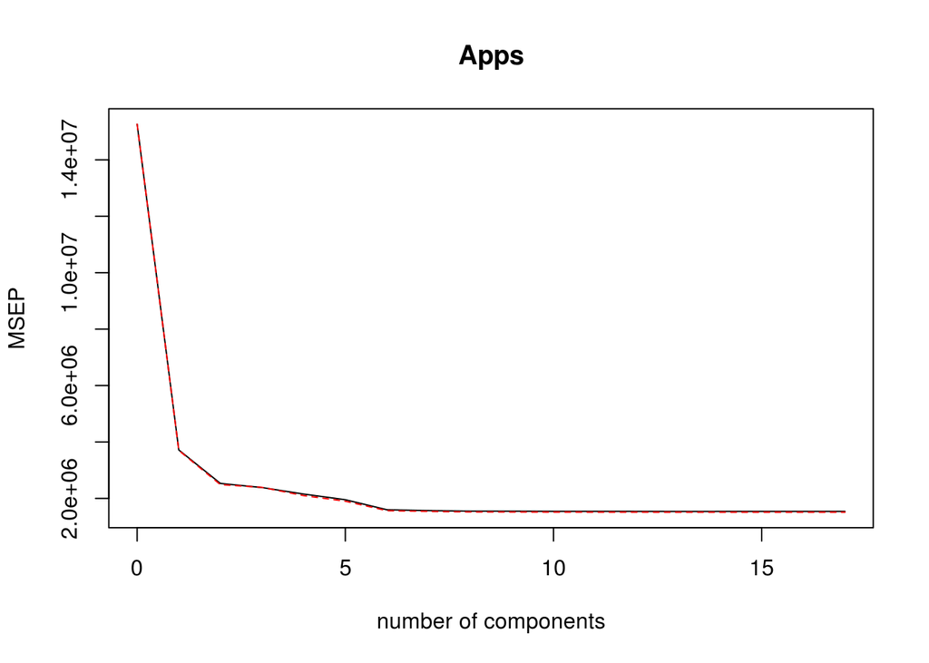

```r
validationplot(pls.fit, val.type = "MSEP")
```

- There is a drastic decrease at first, then levels off past 5
- **The level of M I will use is 8**, since it levels off around then, and minimizes the number of components.

```r
pls.pred = predict(pls.fit, College[-train,], ncomp = 8)

pls_error = mean((pls.pred-test_y)^2)
pls_error
```

```
## [1] 1002220
```

- The PLS test MSE is 1.0022210^{6}
- The PLS model outperforms all other models.

### (g) Comment on the results obtained. How accurately can we predict the number of college applications received? Is there much difference among the test errors resulting from these five approaches?

```r
all_errors = cbind(linear_error, ridge_error, pls_error, lasso_error, pcr_error)
all_errors
```

```
##      linear_error ridge_error pls_error lasso_error pcr_error
## [1,]      1010347     1150592   1002220     1075249   1010347
```

- Based on the results, we can conclude that the “ranking” of models are:
  - 1. PLS: Lowest error rate of 1.0022210^{6}
  - 2. Linear: Error rate of 1.01034710^{6}
  - 3. PCR: Error rate of 1.01034710^{6}
  - 4. Lasso: Error rate of 1.075248710^{6}
  - 5. Ridge: Error rate of 1.150592210^{6}

#### Calculating R-Squared values

- Since I am more used to R-Squared values, I decided to manually calculate it

```r
rsq = function (predicted, actual) {
  return(1 - (sum((predicted - actual) ^ 2)/sum((actual - mean(actual)) ^ 2) ))
}

rsq(pls.pred, test_y)
```

```
## [1] 0.9300404
```

```r
rsq(linear_predicted, test_y)
```

```
## [1] 0.9294731
```

```r
rsq(pcr.pred, test_y)
```

```
## [1] 0.9294731
```

```r
rsq(lasso.pred, test_y)
```

```
## [1] 0.9249427
```

```r
rsq(ridge.pred, test_y)
```

```
## [1] 0.9196834
```

- All of our models perform well, with R-Squared accuracies if over 90%
- Our models vary from 93% to 91.96% R-Squared accuracy